# Supplementary_figures

2025-01-24

# Supplementary Fig. 1

This Figures represents the Time to recovery and Time to impact metrics for each taxa in each biome, and uses the same rationale as the main figure 1. See [`NatPoKe_Task2_Sps_resilience_figure.R`](https://github.com/andrepsilvadev/NatPoKe/blob/dev/src/NatPoKe_Task2_Sps_resilience_figures.R) script for the code.

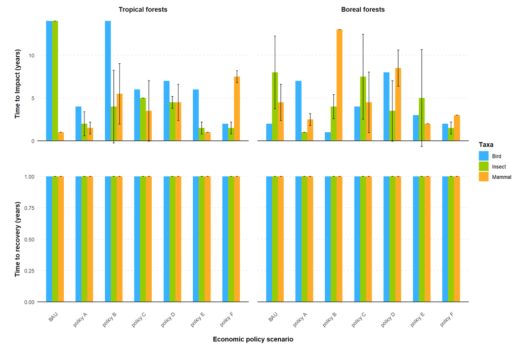

```r
source(here("src", "NatPoKe_Task2_Sps_resilience_figures.R"))
suplementary_figure1
```

# Supplementary Fig. 2

The next figures represents the functional diversity and species richness over time for analysed taxa, using the same rationale as the the second main figure with the Shannon Wiener over time. See [`NatPoKe_Task2_Community_metrics_figures.R`](https://github.com/andrepsilvadev/NatPoKe/blob/dev/src/NatPoKe_Task2_Community_metrics_figures.R) for the script.

## Functional diversity over time

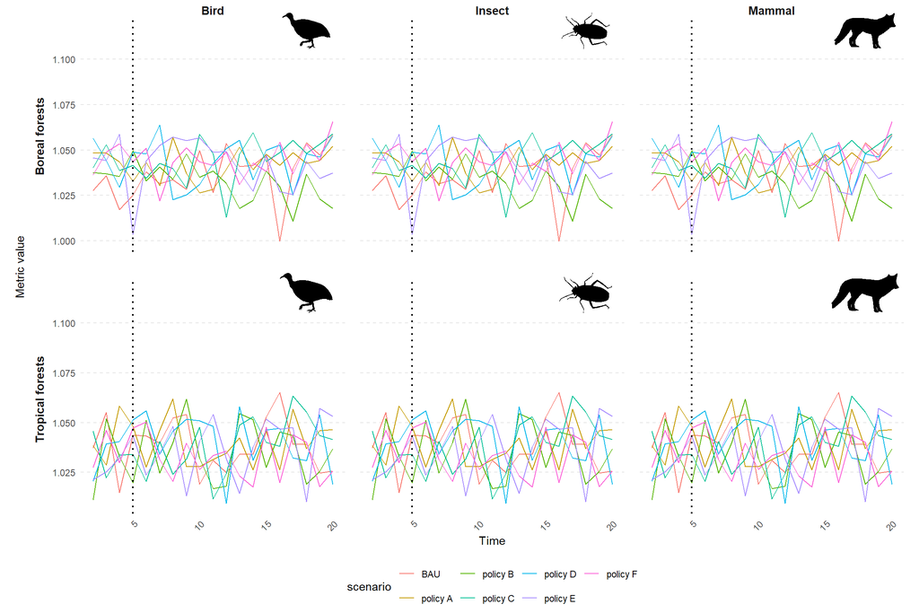

```r
functdiv_over_time
```

## Species Richness

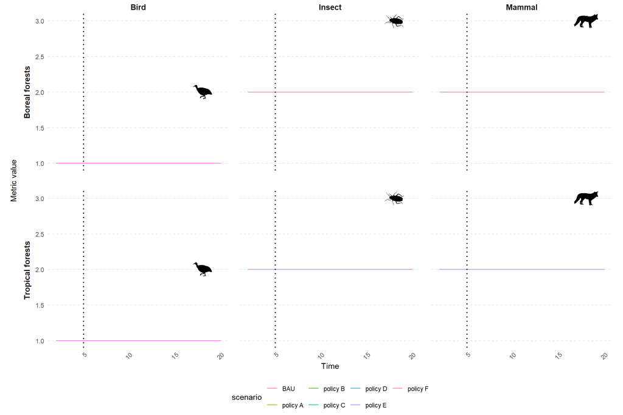

```r
richness_over_time
```

# Supplementary Fig. 3

Supplementary figure 3 will be the same as the main with the Spatially explicit maps of the Shannon Wiener Index per taxa. Most likely mammals will be in the main Figure and the remaining taxa go to the supplementary materials. So there will be as many Supplementary figures 3 as taxa.

See [`NatPoKe_Task2_Spatially_explicit_maps.R`](https://github.com/andrepsilvadev/NatPoKe/blob/dev/src/NatPoKe_Task2_Spatially_explicit_maps.R) for code to produce spatially explicit maps for all taxa in al regions.

**THIS SCRIPT WAS TOO HEAVY TO RUN HERE IN THE HTML TOGETHER WITH ALL THE OTHERS. SEE THE ACTUAL SCRIPT FOR MORE DETAILS OR DUMMY FIGURES FOLDER**

```r
#mammals_plots
```

# Model Validation

> Model validation is the process of determining whether the model accurately represents the behavior of the system (Aumann, 2007). Model validity should be evaluated both operationally (i.e., by determining if model output agrees with observed data) and conceptually (i.e., by determining whether the theory and assumptions underlying the model are justifiable; Sargent, 1984; Rykiel, 1996).

FIrst step on Model Validation is to **Process Indenpendent Density Data**, for now this is teh dataframe provided in Santini et al. 2022, by filtering teh target species and selecting relevant columns (lw95, lw75, PredMd).

Then we need to **Process Extimated Data**, coming from the model output, again by filtering the target species, but this time for a specific **validationYear**. If we are using the raw dataset (exactely as it comes out of the model) we need to average the abundance of each species per cell, by grouping per species and cellid.

After, we add the **spData** with target species traits and select the ModellingResolution. In this case, and specifically for RangeShifter, the Modelling Resolution was calculated from the *Starting density per cell (individuals/cell) = IndsHaCell* retrieved from Santini et al. 2022.

In Step 4, we need to actually **Calculate the estimated density by the model** my dividing the mean number of individuals per cell (meanNInd) with the Modelling resolution (ModellingRes).

Finally we **Combine independentDensity and estimatedDensity into a list**, so we can access them later to produce the model validation figure.

Code for model validation in [`NatPoKe_Model_validation.R`](https://github.com/andrepsilvadev/NatPoKe/blob/dev/src/NatPoKe_Model_validation.R)

```r
source(here("src", "NatPoKe_Model_validation.R"))
```

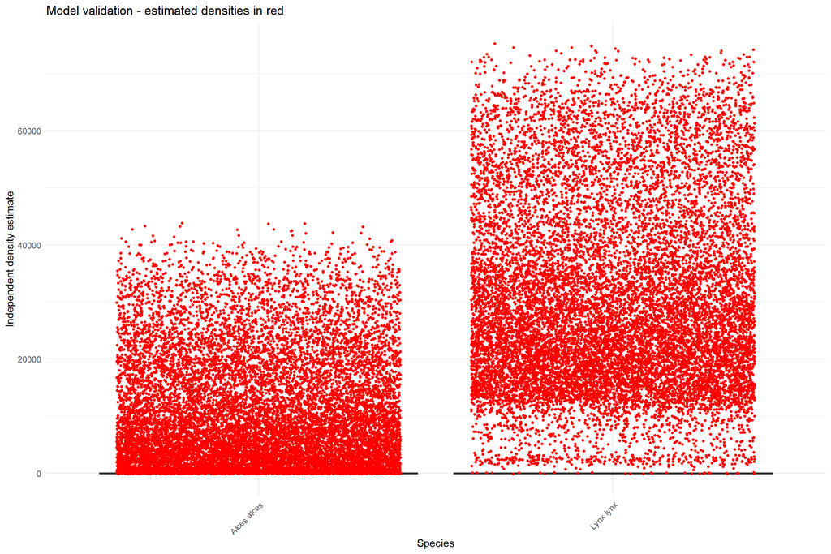

```r
pvalidation1
```

# Sensitivity Analysis

To have the model sensitivity analysis plot, we first ran the model again changing the parameters by +5% and -5%. **In this dummy try we changed reproduction rate by 5%**

Then files are imported directly from the raster format and read as a dataframe with cell coordinates, being separated by sensitivity runs (data_105, data_095 and data_control).

Steps to loop over species: + Step 1 - create an empty list for each species + Step 2 - find & import rasters per variable + Step 3 - Read raster + Step 4 - extract file name info to use later as data column + Step 5 - convert raster to dataframe + Step 6 - Add new columns with needed info (like scenario name, region or biome) + Step 7 - store data in the list created in step 1 + Step 8 - Merge all raster data fro the species (because previous steps do this for each variable it finds) - use reduce function beacuase it is more effcient with big data + Step 9 - Save data

CLEAN UP & RUN GARBAGE COLLECTION COMMAND **OR R WILL ABORT!**

This process repeats for each of the sensitivity runs.

Write final data for each run into a .tsv file.

To build the plot use facets for each variable, and jitter points for each species. Horizontal lines exist for the thresholds th model should not overpass (0.8 and 1.2, 20% chnage).

Here since data is often big several notes exist in the script to handle and dela with that. Read comments carefully to avoid R aborting session even when using Gaias servers.

Code for Sensitivity analysis in [`NatPoKe_Sensitivity_analysis.R`](https://github.com/andrepsilvadev/NatPoKe/blob/dev/src/NatPoKe_Sensitivity_analysis.R)

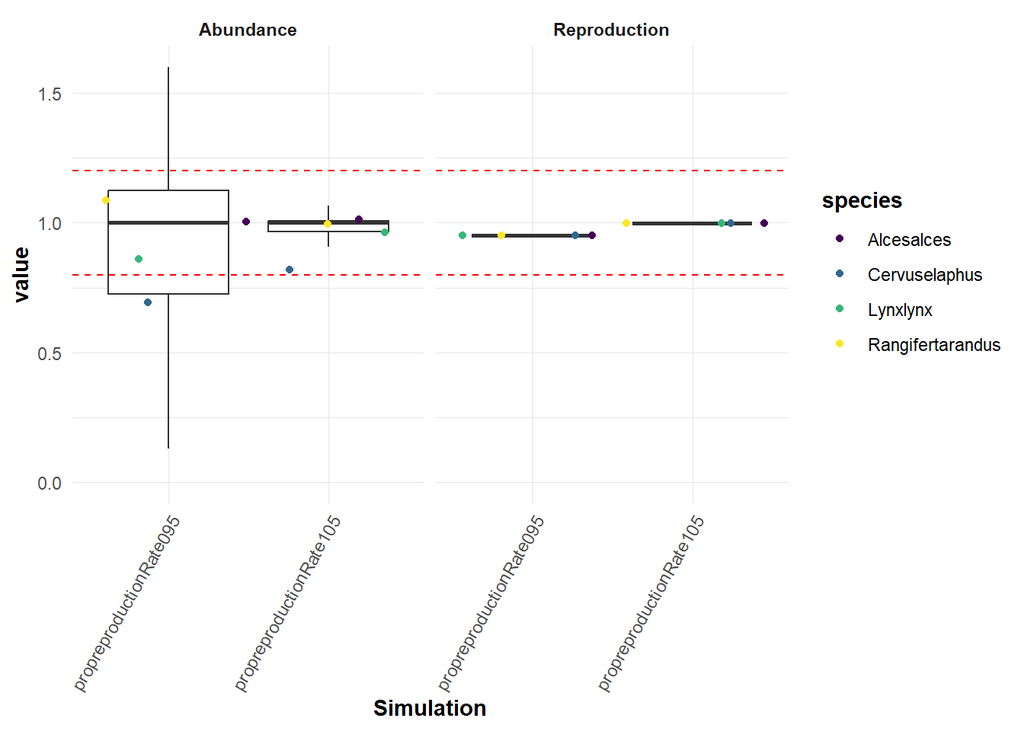

```r
sens_analysis
```